# 2026-03-07-probability-density-function

## Probability Density Function

A probability density function (PDF) is a mathematical function used in statistics to describe the relative likelihood of a continuous, random variable taking on a particular value. In other words, it is a function that provides the probability distribution of a continuous, random variable.

**Probability Distribution**: A probability distribution describes the likelihood of different outcomes in a random experiment. It provides the probabilities of all possible events associated with a random variable, helping to understand how likely each outcome is.

*Discrete vs. Continuous*: Discrete means dealing with a countable amount of possible outcomes. A continuous variable can take on any value within a range, therefore, there is an infinite amount of possibles outcomes.

**Density Curve**: A density curve is a graph that represents a continuous probability distribution. It gives you an idea of the '*shape*' of a distribution. Like, for instance, the well-known, bell-shaped density curve of a normal distribution. The area under the curve is equal to 1.

**Cumulative Distribution Function**: The integral of the PDF for an interval provides the probability that the variable occurs in that interval. This function is called the cumulative distribution function (CDF). You can think of the CDF as the function that provides the area under the density curve between two points.

$f(x)=\frac{dF(x)}{dx}$

$F(x)=Pr(X \leq x)$

$F(x)=\int_{-\infty}^{x}f(t)dt$

Where:

- f is probability density function
- F is the cumulative distribution function

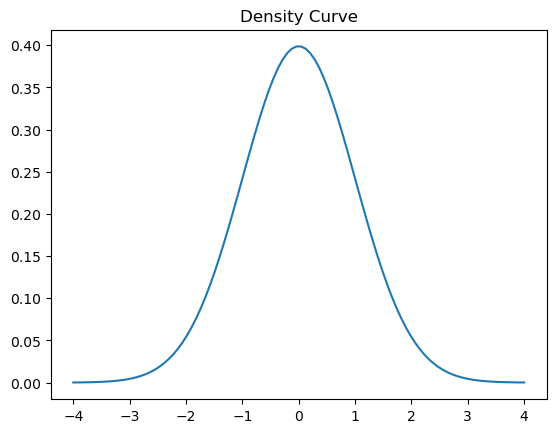

```python
from scipy.stats import norm
import numpy as np
import matplotlib.pyplot as plt

x = np.linspace(-4, 4, 100)
plt.title("Density Curve")
plt.plot(x, norm.pdf(x))
```

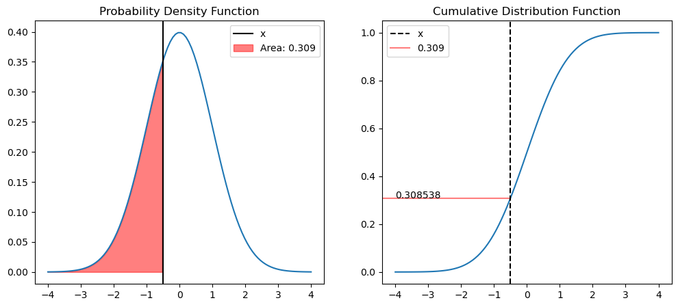

```python
from scipy.integrate import quad

obs = -0.5
auc = [[x,y] for x, y in zip(x, norm.pdf(x)) if x <= obs]
prob = quad(norm.pdf, -np.inf, obs)[0]

plt.figure(figsize=(12,5))
plt.subplot(1,2,1)
plt.title("Probability Density Function")
plt.plot(x, norm.pdf(x))
plt.axvline(obs, c="black", label="x")
plt.fill_between([i[0] for i in auc], [i[1] for i in auc], color="red", alpha=0.5, label=f"Area: {prob:.3f}")
plt.legend()

plt.subplot(1,2,2)
plt.title("Cumulative Distribution Function")
plt.plot(x, norm.cdf(x))
plt.axvline(obs, c="black", linestyle="dashed", label="x")
x_max = (norm.ppf(prob) - min(x)) / (max(x) - min(x))
plt.axhline(prob, color="red", alpha=0.5, xmax=x_max, label=f"{prob:.3f}")
plt.text(min(x), prob, f"{prob:.6f}")
plt.legend()
```

The probability that a random variable X falls within an interval [a,b]:

$Pr(a \leq X \leq b)=\int_{a}^{b}f(x)dx$

$Pr(-\infty \leq X \leq \infty)=\int_{-\infty}^{\infty}f(x)dx=1$

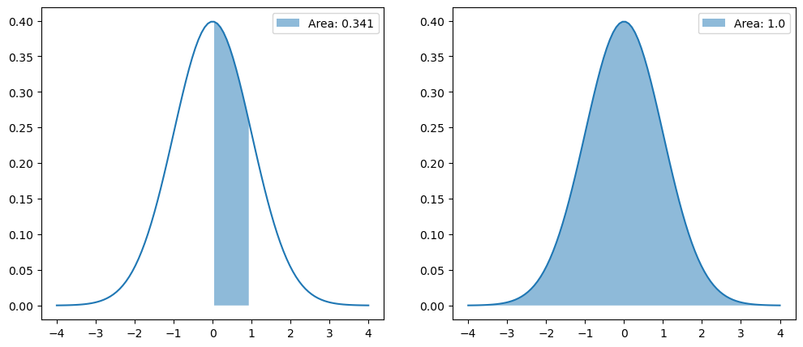

```python
a = 0
b = 1
auc = [[x,y] for x, y in zip(x, norm.pdf(x)) if a <= x <= b]
prob = np.round(quad(norm.pdf, a, b)[0], 3)

plt.figure(figsize=(12,5))
plt.subplot(1,2,1)
plt.plot(x, norm.pdf(x))
plt.fill_between([i[0] for i in auc], [i[1] for i in auc], alpha=0.5, label=f"Area: {prob}")
plt.legend()

prob = np.round(quad(norm.pdf, -np.inf, np.inf)[0], 3)
plt.subplot(1,2,2)
plt.plot(x, norm.pdf(x))
plt.fill_between(x, norm.pdf(x), alpha=0.5, label=f"Area: {prob}")
plt.legend()
```

### Normal Probability Density Function

$X\sim\mathcal{N}(\mu,\sigma^2)$

$f(x,\mu,\sigma)=\frac{1}{\sigma\sqrt{2\pi}}e^{-\frac{1}{2}(\frac{x-\mu}{\sigma})^2}$

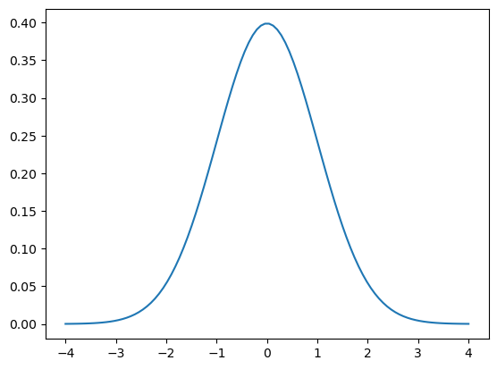

```python
import math

def normal_pdf(x, mu, sigma):
    return np.exp(-np.square((x - mu) / sigma) / 2) / (sigma * np.sqrt(2 * math.pi))

plt.plot(x, normal_pdf(x, mu=0, sigma=1))
```